# Analysis of Variance

Dylan Maddux

2024-10-18

**Statistics student Dominic Kelly decided to study whether ants have a preference among different types of sandwiches for his class project. He found a nice big ant hill, and obtained sandwiches of the following types: Peanut butter, Ham with pickles, and Vegemite. Dominic broke the sandwiches up so that he had 8 sandwich fragments of each type, for a total of n = 24 fragments. For each trial, he placed a sandwich fragment at a specified distance from his ant hill, waited for a while (the same amount of time in each trial), and then counted the number of ants on and immediately around the sandwich fragment. He then removed the fragment, waited a longer time for the ants to return to their hill, and then performed the next trial. To avoid bias and facilitate better conclusions, he randomized the ordering of the 24 trials.**

```r
library(dplyr)
```

**Question 1** Fit the ANOVA model and obtain the model coefficients.

```r
SandwichAnts <- read.csv('data/SandwichAnts1.csv')
mod1 <- lm(Ants~Type, SandwichAnts)
summary(mod1)
```

```
##
## Call:
## lm(formula = Ants ~ Type, data = SandwichAnts)
##
## Residuals:
##     Min      1Q  Median      3Q     Max
## -15.250 -10.312   0.000   9.188  25.000
##
## Coefficients:
##                   Estimate Std. Error t value Pr(>|t|)
## (Intercept)         49.250      4.164  11.827 9.51e-11 ***
## TypePeanut Butter  -15.250      5.889  -2.590  0.01710 *
## TypeVegemite       -18.500      5.889  -3.142  0.00493 **
## ---
## Signif. codes:  0 '***' 0.001 '**' 0.01 '*' 0.05 '.' 0.1 ' ' 1
##
## Residual standard error: 11.78 on 21 degrees of freedom
## Multiple R-squared:  0.3489, Adjusted R-squared:  0.2869
## F-statistic: 5.627 on 2 and 21 DF,  p-value: 0.01105
```

**Question 2** Give the ANOVA table and report your conclusion based on the p-value for the F-test. Can you draw a causal inference here? Do you think your conclusion generalizes to the population?

```r
anova(mod1)
```

```
## Analysis of Variance Table
##
## Response: Ants
##           Df Sum Sq Mean Sq F value  Pr(>F)
## Type       2   1561  780.50  5.6267 0.01105 *
## Residuals 21   2913  138.71
## ---
## Signif. codes:  0 '***' 0.001 '**' 0.01 '*' 0.05 '.' 0.1 ' ' 1
```

There exists a significant difference in the mean number of ants on each type of sandwich, with Ham w/ pickles sandwiches having the highest mean number of ants and Vegemite sandwiches having the lowest. A causal inference can be made because of the experimental design and random ordering. If ants in general are the population, this conclusion does not generalize since only ants from one specific ant hill were tested.

**Question 3** Plot residuals versus fitted values for this model, and make a normal Q-Q plot of the residuals. Comment on whether the conditions for inference appear to be satisfied for this model.

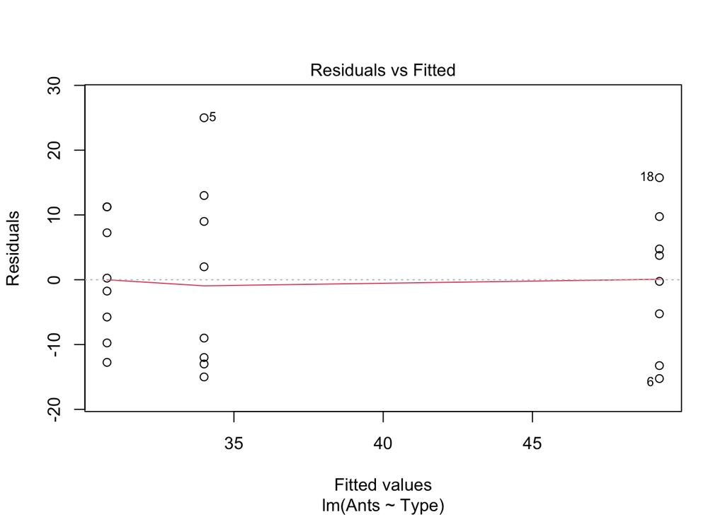

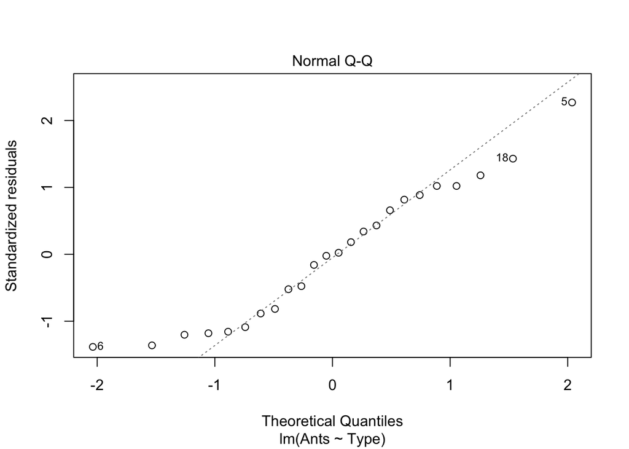

```r
plot(mod1, 1:2)
```

**Question 4** Create two 0/1 indicator variables for the Peanut Butter and Vegemite sandwich types. Refit the model using the lm function with your two indicator variables as predictors, and verify that you get the same model coefficients as you did with Type as a factor variable. How does this ANOVA table relate to the ANOVA table for the first model?

```r
SandwichAnts1 <- SandwichAnts %>%
  mutate(PB = ifelse(Type == "Peanut Butter", 1, 0)) %>%
  mutate(VM = ifelse(Type == "Vegemite", 1, 0))
mod2 <- lm(Ants~PB+VM, SandwichAnts1)
summary(mod2)
```

```
##
## Call:
## lm(formula = Ants ~ PB + VM, data = SandwichAnts1)
##
## Residuals:
##     Min      1Q  Median      3Q     Max
## -15.250 -10.312   0.000   9.188  25.000
##
## Coefficients:
##             Estimate Std. Error t value Pr(>|t|)
## (Intercept)   49.250      4.164  11.827 9.51e-11 ***
## PB           -15.250      5.889  -2.590  0.01710 *
## VM           -18.500      5.889  -3.142  0.00493 **
## ---
## Signif. codes:  0 '***' 0.001 '**' 0.01 '*' 0.05 '.' 0.1 ' ' 1
##
## Residual standard error: 11.78 on 21 degrees of freedom
## Multiple R-squared:  0.3489, Adjusted R-squared:  0.2869
## F-statistic: 5.627 on 2 and 21 DF,  p-value: 0.01105
```

```r
anova(mod2)
```

```
## Analysis of Variance Table
##
## Response: Ants
##           Df Sum Sq Mean Sq F value   Pr(>F)
## PB         1    192  192.00  1.3841 0.252562
## VM         1   1369 1369.00  9.8692 0.004927 **
## Residuals 21   2913  138.71
## ---
## Signif. codes:  0 '***' 0.001 '**' 0.01 '*' 0.05 '.' 0.1 ' ' 1
```

The model coefficients are the same as those for the first model. This ANOVA table is different as it considers two separate predictors (in PB and VM) rather than Type as a single multi-variable predictor.

**Question 5** Create a model with only an intercept. Carry out the nested F-test of your model from question #4 against this intercept-only model, and verify that it recreates the ANOVA table from your model in questions #1 and #2.

```r
mod3 <- lm(Ants ~ 1, data=SandwichAnts1)
anova(mod3, mod2)
```

```
## Analysis of Variance Table
##
## Model 1: Ants ~ 1
## Model 2: Ants ~ PB + VM
##   Res.Df  RSS Df Sum of Sq      F  Pr(>F)
## 1     23 4474
## 2     21 2913  2      1561 5.6267 0.01105 *
## ---
## Signif. codes:  0 '***' 0.001 '**' 0.01 '*' 0.05 '.' 0.1 ' ' 1
```

```r
summary(mod3)
```

```
##
## Call:
## lm(formula = Ants ~ 1, data = SandwichAnts1)
##
## Residuals:
##    Min     1Q Median     3Q    Max
##  -20.0  -13.0   -1.0    9.5   27.0
##
## Coefficients:
##             Estimate Std. Error t value Pr(>|t|)
## (Intercept)   38.000      2.847   13.35 2.57e-12 ***
## ---
## Signif. codes:  0 '***' 0.001 '**' 0.01 '*' 0.05 '.' 0.1 ' ' 1
##
## Residual standard error: 13.95 on 23 degrees of freedom
```

**Question 6** Create a 0/1 indicator variable for the Ham & Pickles sandwich type, and refit the model using only the indicators for Ham & Pickles and Peanut Butter. Verify that you get the same fitted values, but different model coefficients. Verify that you can recreate the same ANOVA table by doing the nested F-test of this model against the intercept-only model.

```r
SandwichAnts2 <- SandwichAnts1%>%
  mutate(HP = ifelse(Type == "Ham & Pickles", 1, 0))
mod4 <- lm(Ants~HP+PB, SandwichAnts2)
summary(mod4)
```

```
##
## Call:
## lm(formula = Ants ~ HP + PB, data = SandwichAnts2)
##
## Residuals:
##     Min      1Q  Median      3Q     Max
## -15.250 -10.312   0.000   9.188  25.000
##
## Coefficients:
##             Estimate Std. Error t value Pr(>|t|)
## (Intercept)   30.750      4.164   7.385  2.9e-07 ***
## HP            18.500      5.889   3.142  0.00493 **
## PB             3.250      5.889   0.552  0.58685
## ---
## Signif. codes:  0 '***' 0.001 '**' 0.01 '*' 0.05 '.' 0.1 ' ' 1
##
## Residual standard error: 11.78 on 21 degrees of freedom
## Multiple R-squared:  0.3489, Adjusted R-squared:  0.2869
## F-statistic: 5.627 on 2 and 21 DF,  p-value: 0.01105
```

```r
anova(mod3, mod4)
```

```
## Analysis of Variance Table
##
## Model 1: Ants ~ 1
## Model 2: Ants ~ HP + PB
##   Res.Df  RSS Df Sum of Sq      F  Pr(>F)
## 1     23 4474
## 2     21 2913  2      1561 5.6267 0.01105 *
## ---
## Signif. codes:  0 '***' 0.001 '**' 0.01 '*' 0.05 '.' 0.1 ' ' 1
```

**Question 7** What happens if you fit the model using all three 0/1 indicator variables? This illustrates the fact that we only have g – 1 “degrees of freedom” when modeling a categorical variable with g levels.

```r
mod5 <- lm(Ants~HP+PB+VM, SandwichAnts2)
summary(mod5)
```

```
##
## Call:
## lm(formula = Ants ~ HP + PB + VM, data = SandwichAnts2)
##
## Residuals:
##     Min      1Q  Median      3Q     Max
## -15.250 -10.312   0.000   9.188  25.000
##
## Coefficients: (1 not defined because of singularities)
##             Estimate Std. Error t value Pr(>|t|)
## (Intercept)   30.750      4.164   7.385  2.9e-07 ***
## HP            18.500      5.889   3.142  0.00493 **
## PB             3.250      5.889   0.552  0.58685
## VM                NA         NA      NA       NA
## ---
## Signif. codes:  0 '***' 0.001 '**' 0.01 '*' 0.05 '.' 0.1 ' ' 1
##
## Residual standard error: 11.78 on 21 degrees of freedom
## Multiple R-squared:  0.3489, Adjusted R-squared:  0.2869
## F-statistic: 5.627 on 2 and 21 DF,  p-value: 0.01105
```

One of the dummy variables (VM in this case) drops out due to perfect multicollinearity between the predictors since the indicators sum to one.